# Practical Machine Learning - Course Project

Akira Sano

4/2/2020

## Introduction

In this work, the investigators first define quality of execution and investigate three aspects that pertain to qualitative activity recognition: the problem of specifying correct execution, the automatic and robust detection of execution mistakes, and how to provide feedback on the quality of execution to the user. We tried out an on-body sensing approach (dataset here), but also an “ambient sensing approach” (by using Microsoft Kinect - dataset still unavailable).

Six young health participants were asked to perform one set of 10 repetitions of the Unilateral Dumbbell Biceps Curl in five different fashions: exactly according to the specification (Class A), throwing the elbows to the front (Class B), lifting the dumbbell only halfway (Class C), lowering the dumbbell only halfway (Class D) and throwing the hips to the front (Class E). Class A corresponds to the specified execution of the exercise, while the other 4 classes correspond to common mistakes.

One goal is to apply machine learning techniques to the given accelerometer data to predict whether an observation (a human), with various features recordable in the data, executes the lifting correctly (class A) or not (other classes).

## Data Collection and Cleaning

We download the training and testing data sets and partition the training set into the training (70%) and testing sets (30%). The testing data contains 20 observations and labeled as a validating set. The empty and #DIV/0! entries convert to NAs.

```r
#setwd("Coursera/Machine Learning/")
#download.file("https://d396qusza40orc.cloudfront.net/predmachlearn/pml-training.csv", "pml-training.csv")
dat <- read.csv("pml-training.csv", na.strings = c("NA", "", "#DIV/0!"))
#download.file("https://d396qusza40orc.cloudfront.net/predmachlearn/pml-testing.csv", "pml-testing.csv")
validating <- read.csv("pml-testing.csv", na.strings = c("NA", "", "#DIV/0!"))
```

The variable “classe” is the class variable.

```r
table(dat$classe)
```

```
##
##    A    B    C    D    E
## 5580 3797 3422 3216 3607
```

We will remove unnecessary columns from the set dat, for prediction such as index (X), and do some data cleaning (remove columns with very few observations), then partition it into training and testing set.

```r
#Remove "X" column (row index)
dat <- subset(dat, select = -X)
validating <- subset(validating, select = -X)
```

At this point, every row (observation) has NA in at least one of its columns.

```r
library(caret)
```

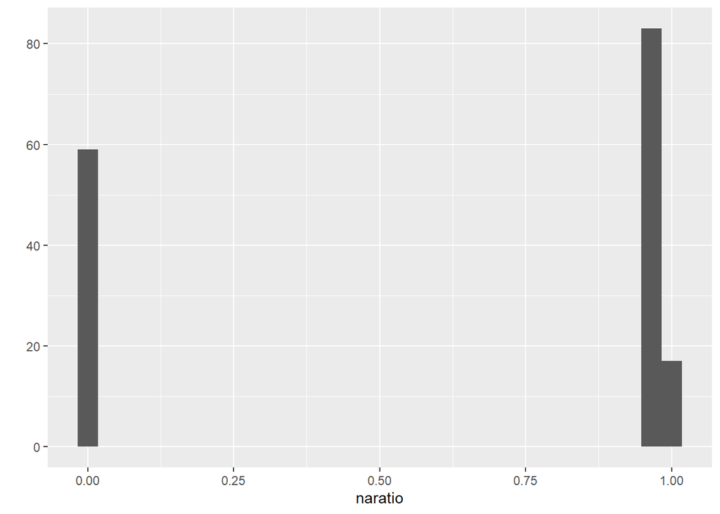

```r
naratio <- sapply( dat, function(x) sum(is.na(x))/dim(dat)[1] )
qplot(naratio)
```

We remove all the columns whose NA rate is greater than 80%.

```r
dat <- subset(dat, select = names(naratio)[naratio < 0.8])
validating <- subset(validating, select = names(naratio)[naratio < 0.8][-59]) # col 59 = classe which is not in validating set
```

Further, remove near-zero-variance variablesfrom dat and align the validating set to it.

```r
tmp <- nearZeroVar(dat, saveMetrics = TRUE)
dat <- subset(dat,  select = rownames(tmp[tmp$nzv == FALSE,]))
validating <- subset(validating,  select = rownames(tmp[tmp$nzv == FALSE,])[-58]) #col 58 = classe
```

raw_timestamp_part_1 is equal to cvtd_timestamp in seconds. We find the correct conversion (and remove cvtd_timestamp) *but do not use it*, and keep the microseconds in raw_timestamp_part_2 as seconds.

```r
#dat$datetime <- as.POSIXct(dat$raw_timestamp_part_1, "%d/%m/%Y %H:%M", origin="1970-01-01")
#validating$datetime <- as.POSIXct(validating$raw_timestamp_part_1, "%d/%m/%Y %H:%M", origin="1970-01-01")
dat$raw_timestamp_part_1 <- NULL
validating$raw_timestamp_part_1 <- NULL
dat$dur <- dat$raw_timestamp_part_2 / 1.0e6
validating$dur <- validating$raw_timestamp_part_2 / 1.0e6
dat$raw_timestamp_part_2 <- NULL
validating$raw_timestamp_part_2 <- NULL

dat <- data.frame(dat[,-56], classe=dat[,56])
dat$cvtd_timestamp <- NULL
validating$cvtd_timestamp <- NULL
```

We now partition dat into the training and testing sets (reproducible).

```r
library(caret)
set.seed(123)
inTrain <- createDataPartition(dat$classe, p = 0.7, list = FALSE)
training <- dat[inTrain,]
testing <- dat[-inTrain,]
```

## Model fits

We use randomForest and gbm packages to train and predict on the test set by cross validating.

```r
ctl <- trainControl(method = "cv", number = 4, allowParallel = TRUE)

fitrf <- train(classe ~., method = "rf", trControl = ctl, data = training)
fitgbm <- train(classe ~., method = "gbm", trControl = ctl, data = training, verbose = FALSE)
```

```r
prf <- predict(fitrf, testing)
pgbm <- predict(fitgbm, testing)
table(prf, testing$classe)
```

```
##
## prf    A    B    C    D    E
##   A 1674    2    0    0    0
##   B    0 1134    1    0    0
##   C    0    3 1025    1    0
##   D    0    0    0  963    3
##   E    0    0    0    0 1079
```

```r
table(pgbm, testing$ classe)
```

```
##
## pgbm    A    B    C    D    E
##    A 1670    5    0    0    2
##    B    3 1117   11   10    0
##    C    0   16 1013    8    5
##    D    0    1    2  946   12
##    E    1    0    0    0 1063
```

```r
table(prf, pgbm)
```

```
##    pgbm
## prf    A    B    C    D    E
##   A 1671    4    0    0    1
##   B    4 1116   14    1    0
##   C    0   11 1016    2    0
##   D    0   10    7  949    0
##   E    2    0    5    9 1063
```

In random forest, if we use the “importance” function, it is possible to glance at which variables are important (in the sense of accuracy drop in prediction if the observation order of that variable is randomly permuted). Out of 50+ variables, one can focus on top 20 such, to speed up the training and not drop the accuracy significantly.

```r
library(randomForest)
```

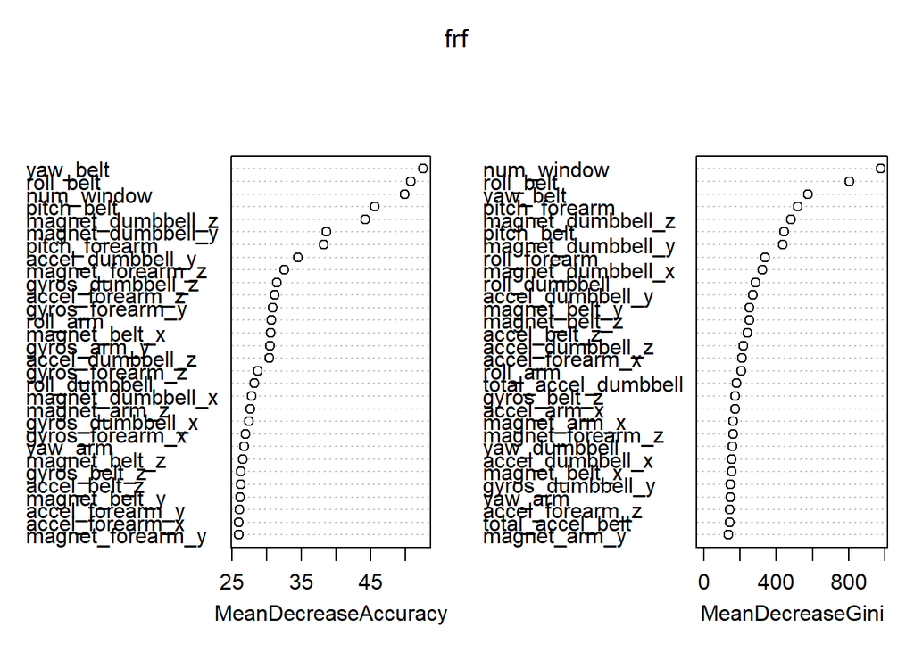

```r
frf <- randomForest(classe ~., data=training, importance = TRUE)
varImpPlot(frf)
```

One tries to combine these models to see if the result is better than each.

```r
library(nnet)
predDF <- data.frame(prf=prf, pgbm=pgbm, classe=testing$classe)
combModFit <- multinom(classe ~., data = predDF)
combPred <- predict(combModFit, newdata = testing)
table(combPred, testing$classe)
```

```
##
## combPred    A    B    C    D    E
##        A 1674    2    0    0    0
##        B    0 1134    1    0    0
##        C    0    3 1025    1    0
##        D    0    0    0  963    3
##        E    0    0    0    0 1079
```

The result is the same as the random forest result. Therefore, we decide to use the random forest result as the final model fit for the validation set.

Finally, using the validation set of 20 observations, the prediction is as follows:

```r
result <- predict(fitrf, newdata = validating)
result
```

```
##  [1] B A B A A E D B A A B C B A E E A B B B
## Levels: A B C D E
```